# Analysis - Daims Nitrospira Comammox ENR6 assembly

Mads Albertsen

November 24, 2015

## Introduction

This report documents the binning of a Nitrospira Comammox genome from an enrichment reactor (ENR6). See [Daims et al., 2015: Complete Nitrification by Nitrospira Bacteria](https://doi.org/10.1038/nature16461) for further details.

## Load the mmgenome package

The metagenome data is analysed using the [mmgenome package](http://madsalbertsen.github.io/mmgenome/).

```r
library("mmgenome")
```

## Import data

The Rmarkdown file [Load_data.Rmd](http://madsalbertsen.github.io/mmgenome/Daims_MBR_Load_data.html) describes the loading of the data and can be imported using the `mmimport` function. However, the preprocessed data can also be downloaded directly from figshare: [Daims_ENR6](http://dx.doi.org/10.6084/m9.figshare.1613282). Hence, here we import the prepocessed data from figshare instead.

```r
load("Daims_ENR6.RData")
```

## Data overview

The object `d` contains information on scaffolds and essential genes within the scaffolds. For each scaffold the dataset contains the following information: The columns `ENR4A`, `ENR4E`, `ENR4F` and `ENR6` contain the coverage information from 4 different samples; `PC1`, `PC2` and `PC3` contain coordinates of the three first principal components from a PCA analysis on tetranucleotide frequencies; `essential` contain information taxonomic information for each scaffold based on classification on essential genes.

```r
colnames(d$scaffolds)
```

```
##  [1] "scaffold"  "length"    "gc"        "ENR4A"     "ENR4E"
##  [6] "ENR4F"     "ENR6"      "PC1"       "PC2"       "PC3"
## [11] "essential"
```

The basic statistics of the full dataset can be summarised using the `mmstats` function.

```r
mmstats(d, ncov = 4)
```

```
##                General Stats
## n.scaffolds           112.00
## GC.mean                63.00
## N50                176895.00
## Length.total      6806891.00
## Length.max        1306334.00
## Length.mean         60775.80
## Coverage.ENR4A        291.73
## Coverage.ENR4E        255.06
## Coverage.ENR4F        469.64
## Coverage.ENR6         283.26
## Ess.total             214.00
## Ess.unique            106.00
```

## Binning of the commamox Nitrospira genome

The combination of the coverage of sample `ENR4A` and `ENR4E` provides the cleanest separation of the two genomes and are used for binning. A subspace is defined that clearly seperates the Nitrospira from the Betaproteobacteria.

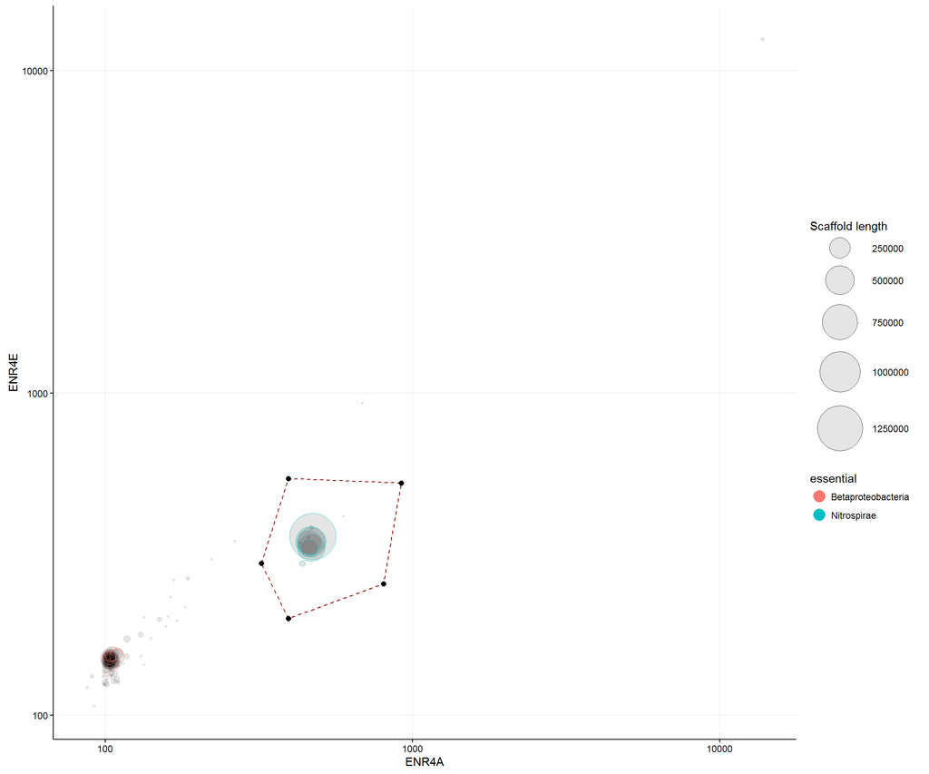

```r
p <- mmplot(data = d, x = "ENR4A", y = "ENR4E", log.x = T, log.y = T, color = "essential")

#p
#sel <- mmplot_locator(p)

sel <- data.frame(ENR4A  =  c(322, 394, 919, 805, 394),
                  ENR4E  =  c(296, 542, 525, 256, 200))

mmplot_selection(p, sel)
```

The scaffolds included in the defined subspace are extracted using the `mmextract` function.

```r
dA <- mmextract(d, sel)
```

The `mmstats` function applies to any extracted object. Hence, it can be used directly on the subset.

```r
mmstats(dA, ncov = 4)
```

```
##                General Stats
## n.scaffolds            11.00
## GC.mean                59.20
## N50                558735.00
## Length.total      3291638.00
## Length.max        1306334.00
## Length.mean        299239.80
## Coverage.ENR4A        468.69
## Coverage.ENR4E        347.57
## Coverage.ENR4F        645.88
## Coverage.ENR6         341.64
## Ess.total             108.00
## Ess.unique            105.00
```

## Export the scaffolds

Now that we are happy with the genome bin, the scaffolds can be exported to a separate fasta file using `mmexport`. The genome were then further reassembled using additional Oxford Nanopore data.

```r
mmexport(data=dA, assembly=assembly, file = "Nitrospira_ENR6.fa")
```

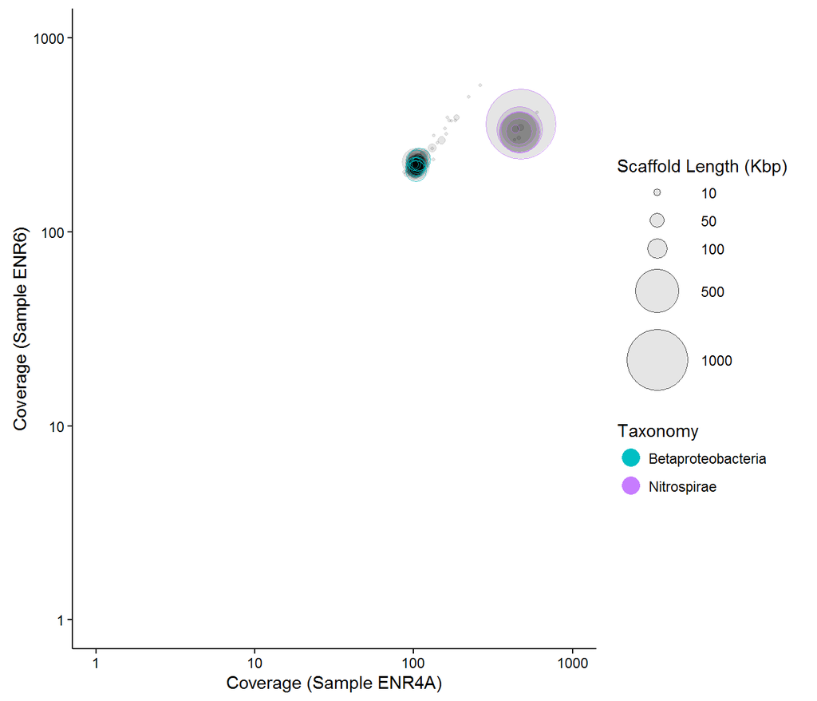

```r
gg_color_hue <- function(n) {
  hues = seq(15, 375, length=n+1)
  hcl(h=hues, l=65, c=100)[1:n]
}
cols = gg_color_hue(4)

mmplot(data = d,
       x = "ENR4A",
       y = "ENR6",
       log.x = T,
       log.y = T,
       color = "essential") +
  scale_x_log10(limits = c(1,1000), breaks = c(1, 10, 100, 1000)) +
  scale_y_log10(limits = c(1,1000), breaks = c(1, 10, 100, 1000)) +
  scale_size_area(breaks = c(10000, 50000,  100000, 500000, 1000000), max_size = 20, labels = c(10, 50, 100, 500, 1000), name = "Scaffold Length (Kbp)") +
  scale_color_manual(name = "Taxonomy", values = cols[c(3,4)]) +
  ylab("Coverage (Sample ENR6)") +
  xlab("Coverage (Sample ENR4A)") +
  theme(panel.background = element_blank(),
        panel.grid.minor = element_blank(),
        panel.grid.major = element_blank(),
        axis.line = element_line(color = "black"),
        axis.ticks = element_line(color = "black"),
        axis.text = element_text(color = "black"),
        legend.key = element_blank())
```